# Simulating clinical trials, gamma-poisson models

Steve Simon

March 22, 2017

### Part 3. Gamma Poisson models

From this point onward, you’ll be seeing summarizations of the simulations using boxplots and scatterplots, but it’s worth remembering that behind these graphs are thousands of random paths. The simulation of total sample size for a fixed time frame is a Poisson model with an informative gamma prior.

### Figure 3.1. Boxplot of prior distribution for accrual rate.

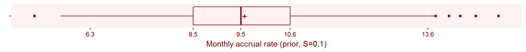

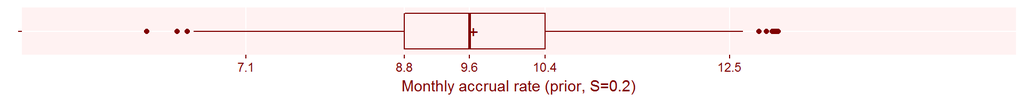

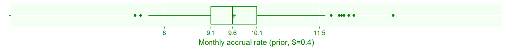

Selecting a prior distribution requires a lot of work. It helps, I believe to express the strength of the prior distribution as a fraction of the planned sample size. A prior with a strength equivalent to 40% of the planned sample size represents a setting you give equal weight to the prior distribution and the data when you have collected 40% of the data. That’s a very strong prior, but not unreasonable. As a researcher who has done this sort of clinical trial many times, the value of S=0.4 seems like the best choice to you.

### Stan code for the gamma-Poisson model

```
## data {
##   int<lower=1>           N; // planned number of patients
##   int<lower=0>           n; // observed patients
##   real<lower=0, upper=1> S; // strength of prior
##   real<lower=0>          T; // planned duration of trial
##   real<lower=0>          t; // observed time
## }
## parameters {
##   real<lower=0> lambda;
## }
## model {
##   lambda ~ gamma(N*S, T*S);
##   if (t>0) n ~ poisson(t*lambda);
## }
## generated quantities {
##   real<lower=0> Nstar;
##   Nstar = n + poisson_rng((T-t)*lambda);
## }
```

### Figure 3.2. Simulated total sample size prior to start of clinical trial.

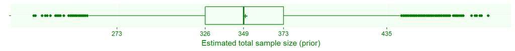

The center of the boxplot represents the median sample size from the simulation, and it is close to our target. The spread in the boxplot is caused by the random nature of patient accrual and uncertainty associated with the Poisson rate parameter.

### Figure 3.3. Relationship of prior estimate of accrual rate and estimated total sample size.

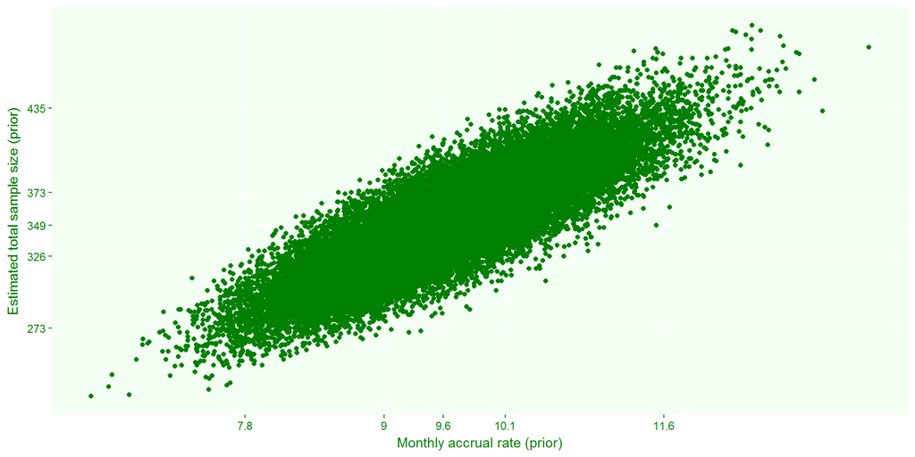

You can learn a lot by looking at how the estimated total sample size relates to the prior paramter(s).

Recall that in this simulation, you randomly select an accrual rate, gamma, and then you simulate a path based on that value of lambda. Not too surprisingly, the sample size depends on what lambda is chosen, though there is some variation, even for the same value of lambda.

### Figure 3.4. Relationship of fixed accrual estimate and estimated total sample size.

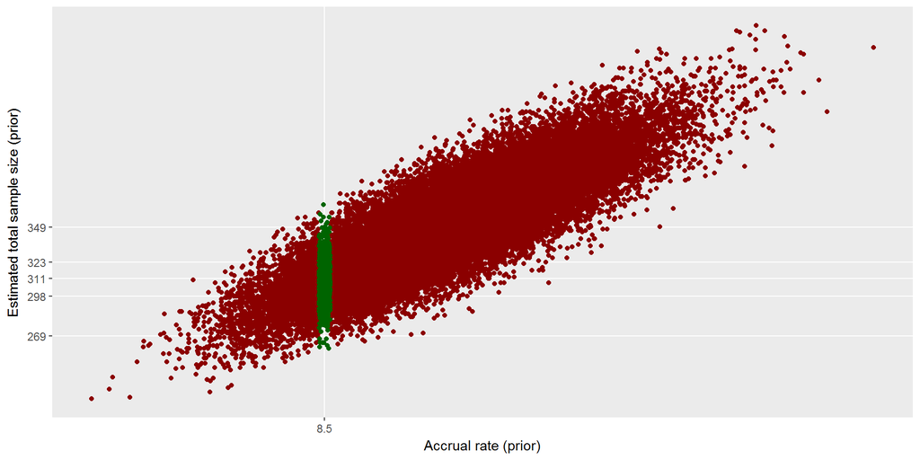

With a plot like this, you can run some sensitivity checks, such as “what would happen if the accrual rate were closer to 8.5 patients per month”

### Update

The key reason that you should run your simulations in a Bayesian framework is that you can make a seamless transition to a simulation of a clinical trial during the trial itself. In this trial, the early accrual rate was much lower than expected. After 239 days, you have only gotten 41 patients. If you were on target, it would have taken only 1095*(41/350) = 128 days to get this many patients. How much is this shortfall hurting us?

### Figure 3.5. Simulated total sample size during the clinical trial.

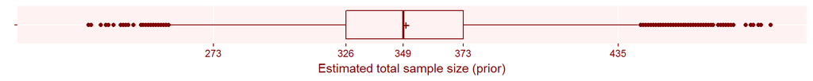

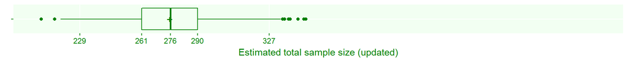

### Post mortem analysis

For this trial, you were able to get 341 patients, but it took a lot longer than you expected, 1336 days instead of 1095 days. Time to get ready for your next clinical trial. NOT SO FAST! You are not done with simulations when the trial is over. After the trial, take a look at how your accrual rate ranks relative to the range of accrual rates associated with your prior distribution.

### Figure 3.6. Comparison of final accrual rate to prior distribution.

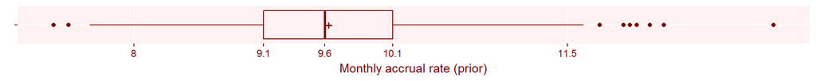

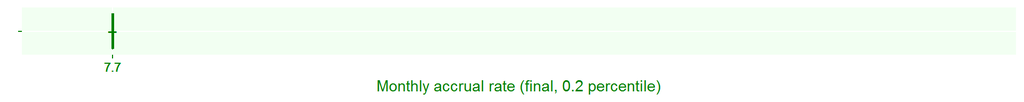

Okay, so you were way off. No one is going to hang you. But let’s look at your other clinical trials.

### Figure 3.7. Percentile plot showing bias to low end.

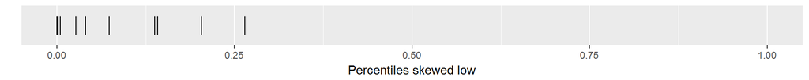

When you are estimating accrual, a low percentile means that the final data from all of your clinical trials is in the lower tail of your prior distribution. So a plot where most or all of the percentiles fall below 50% means that you have a overly optimistic assessment of accrual before most of your trials.

### Figure 3.8. Percentile plot showing bias to extremes.

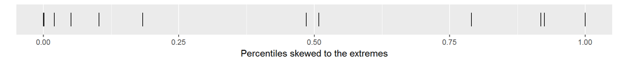

Another pattern to look for is a tendency to fall at either extreme. This means that your prior distributions are too narrow and you have too much confidence in your ability to assess accrual rates. Maybe in the future, you should choose wider prior distributions (smaller values of S).

### Figure 3.9. Percentile plot showing relatively even spread.

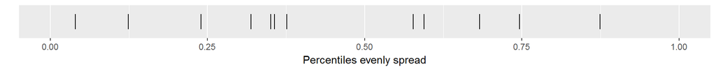

Just for perspective, here is a what a percentile plot might look like if your prior distributions were reasonably accurate. You tend to see (albeit very roughly) about as many percentiles above and below 50% and about as many in the middle (between 25% and 75%) as you do outside the middle.